# Data Visualization Report (Act Report)

This report communicates all the insights and displays the visualization(s) produced from my wrangled data. The wrangle data underg the process of data gathering, assesing and cleaning in order to have a good display of visuals which ultimatley gave good insight into the data. Stated below are the report on the visualizations performed on the wrangled data.

#### Dog Rating Distribution

I was able to determine the Dog rating distribution by plotting the histogram of Dog rating distribution as against the frequency it occurs. My observations clearly show that the Dog Ratings distribution is skewed to the left, meaning that most of the ratings falls between 10 and 14

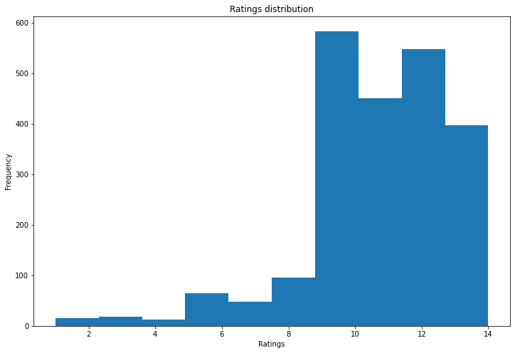

#### Top 50 Dogs with the highest ratings

Second, I determined the top 50 Dogs with the highest ratings by plotting the histogram histogram Dog names against the ratings. My observation from the resulting graph shows that 21 Dogs has the same rating value of 14, while 29 Dogs has rating value of between 13 and less than 14 rating value out of the top 50 Dog ratings.

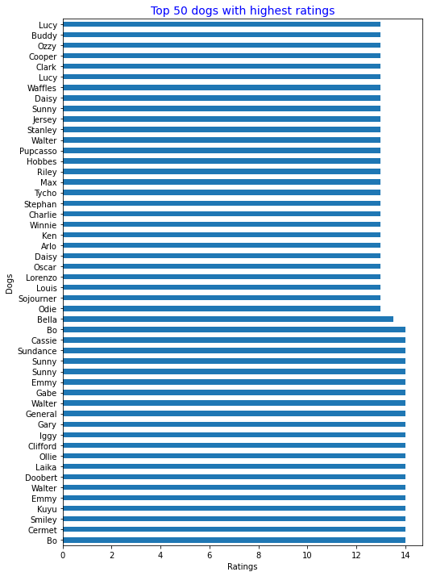

#### Most common dog breed or stage

Third, I determined the most common dog breed which was named dog stage in the dataset. Pupper appears to have the highest Dog breed or stage followed by Doggo, Puppo and Floofer respectively.

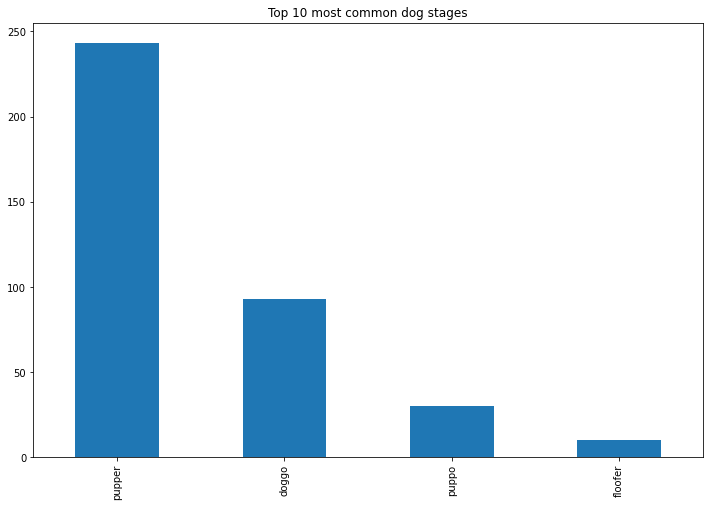